# Practical 2

Hsuan Lee

```r
library(ISLR)
library(tidyverse)
```

# What is ggplot ?

1. Name the aesthetics, geoms, scales, and facets of the above visualisation. Also name any statistical transformations or special coordinatesystems.

aesthetic : x indicates the number of hits, y indicates the number of home runs

geom_point : each point in the plot is a baseball player with the specific hits and home runs number

geom_density_2d: indicates the density of player’s points distribution.

scales: x-axis is continuous, y axis is continuous.

facet: it is a 2 dimension plot

# Aesthetics and data preparation

2. Run the code below to generate data. There will be three vectors in your environment. Put them in a data frame for entering it in a ggplot() callusing either the data.frame() or the tibble() function. Give informative names and make sure the types are correct (use the as.() functions). Name the result gg_students

```r
set.seed(1234)
student_grade <- rnorm(32, 7)
student_number <- round(runif(32) + 2e6 + 5e6)
programme <- sample(c("Science", "Social Sciemce"), 32, replace = T)
```

```r
gg_students <- data.frame(student_grade, student_number, programme)
```

3. Plot the first homeruns_plot again, but map the Hits to the y-axis and the HmRun to the x-axis instead.

```r
head(Hitters)
```

```
##                   AtBat Hits HmRun Runs RBI Walks Years CAtBat CHits CHmRun
## -Andy Allanson      293   66     1   30  29    14     1    293    66      1
## -Alan Ashby         315   81     7   24  38    39    14   3449   835     69
## -Alvin Davis        479  130    18   66  72    76     3   1624   457     63
## -Andre Dawson       496  141    20   65  78    37    11   5628  1575    225
## -Andres Galarraga   321   87    10   39  42    30     2    396   101     12
## -Alfredo Griffin    594  169     4   74  51    35    11   4408  1133     19
##                   CRuns CRBI CWalks League Division PutOuts Assists Errors
## -Andy Allanson       30   29     14      A        E     446      33     20
## -Alan Ashby         321  414    375      N        W     632      43     10
## -Alvin Davis        224  266    263      A        W     880      82     14
## -Andre Dawson       828  838    354      N        E     200      11      3
## -Andres Galarraga    48   46     33      N        E     805      40      4
## -Alfredo Griffin    501  336    194      A        W     282     421     25
##                   Salary NewLeague
## -Andy Allanson        NA         A
## -Alan Ashby        475.0         N
## -Alvin Davis       480.0         A
## -Andre Dawson      500.0         N
## -Andres Galarraga   91.5         N
## -Alfredo Griffin   750.0         A
```

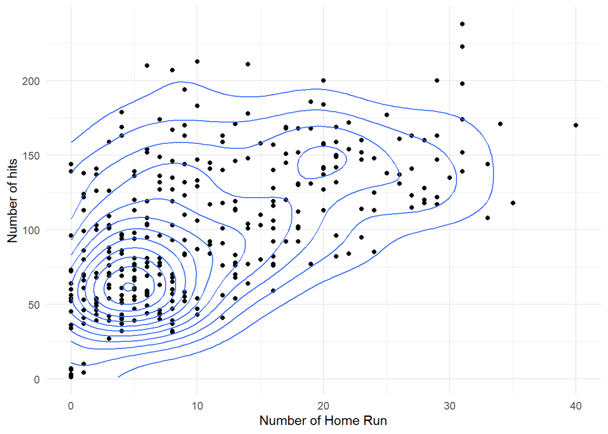

```r
Hitters %>%
  ggplot(aes(x = HmRun, y = Hits)) +
  geom_point() +
  geom_density2d() +
  labs(x = "Number of Home Run", y = "Number of hits") +
  theme_minimal()
```

4. Recreate the same plot once more, but now also map the variable League to the colour aesthetic and the variable Salary to the size aesthetic.

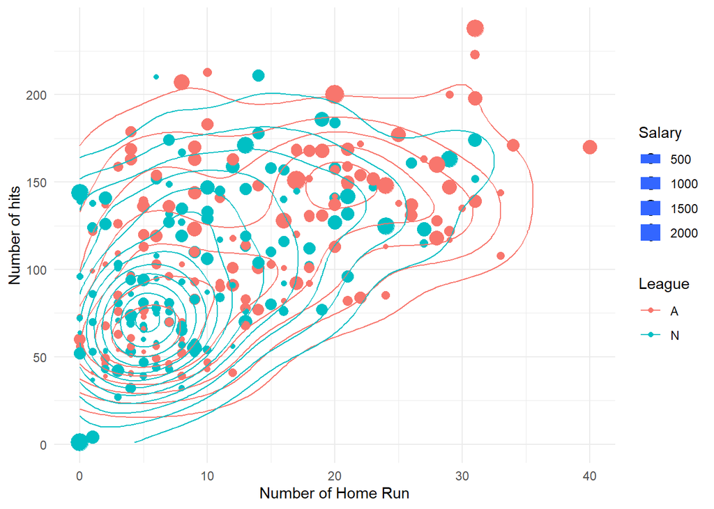

```r
Hitters %>%
  drop_na() %>%
  ggplot(aes(x = HmRun, y = Hits, color = League, size = Salary)) +
  geom_point() +
  geom_density2d() +
  labs(x = "Number of Home Run", y = "Number of hits") +
  theme_minimal()
```

5. Look at the many different geoms on the reference website (https://ggplot2.tidyverse.org/reference/#section-layer-geoms) .
6. Use geom_histogram() to create a histogram of the grades of the students in the gg_students dataset. Play around with the binwidth argument of the geom_histogram() function.

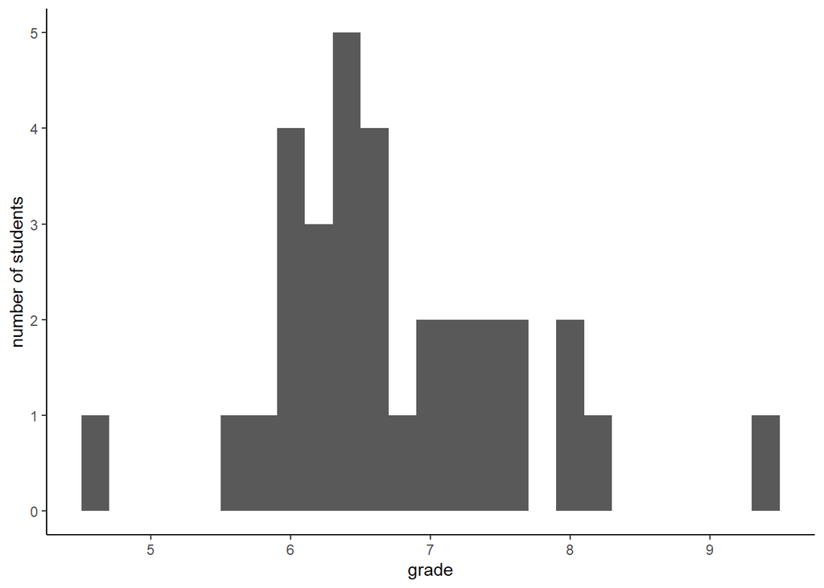

```r
ggplot(data = gg_students, aes(x = student_grade)) +
  # set the width of each bin along the X-axis
  geom_histogram(binwidth = 0.2) +
  labs(x = "grade", y = "number of students") +
  theme_classic()
```

7. Use geom_density() to create a density plot of the grades of the students in the gg_students dataset. Add the argument fill = “light seagreen” to geom_density() .

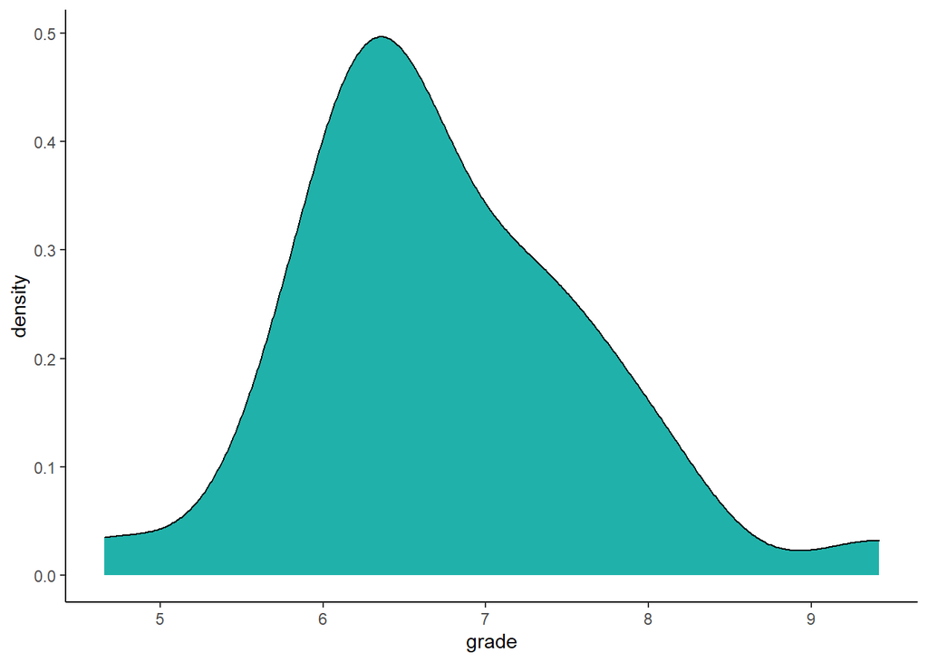

```r
ggplot(data = gg_students, aes(x = student_grade)) +
  geom_density(fill = "light seagreen") +
  labs(x = "grade") +
  theme_classic()
```

8. Add rug marks to the density plot through geom_rug() . You can edit the colour and size of the rug marks using those arguments within the geom_rug() function.

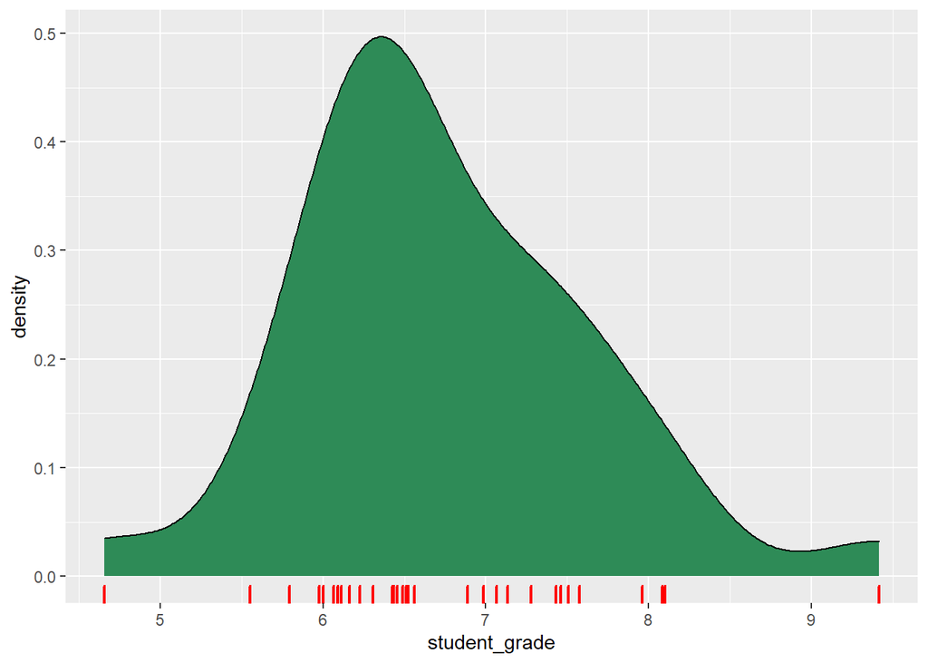

```r
ggplot(data = gg_students, aes(x = student_grade)) +
  geom_density(fill = "seagreen") +
  geom_rug(color = "red", size = 0.8)
```

9. Increase the data to ink ratio by removing the y axis label, setting the theme to theme_minimal() , and removing the border of the density polygon.Also set the limits of the x-axis to go from 0 to 10 using the xlim() function, because those are the plausible values for a student grade.

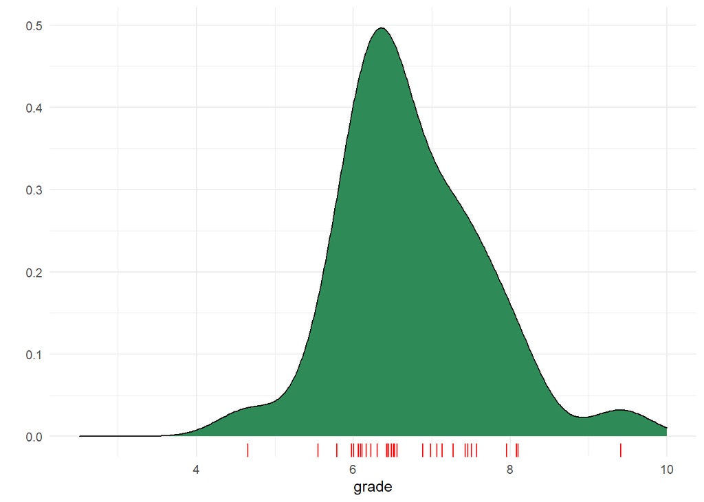

```r
ggplot(data = gg_students, aes(x = student_grade)) +
  geom_density(fill = "seagreen") +
  geom_rug(color = "red", size = 0.5) +
  labs(x = "grade", y = "") +
  theme_minimal() +
  xlim(2.5, 10)
```

10. Create a boxplot of student grades per programme in the gg_students dataset you made earlier: map the programme variable to the x positionand the grade to the y position. For extra visual aid, you can additionally map the programme variable to the fill aesthetic.

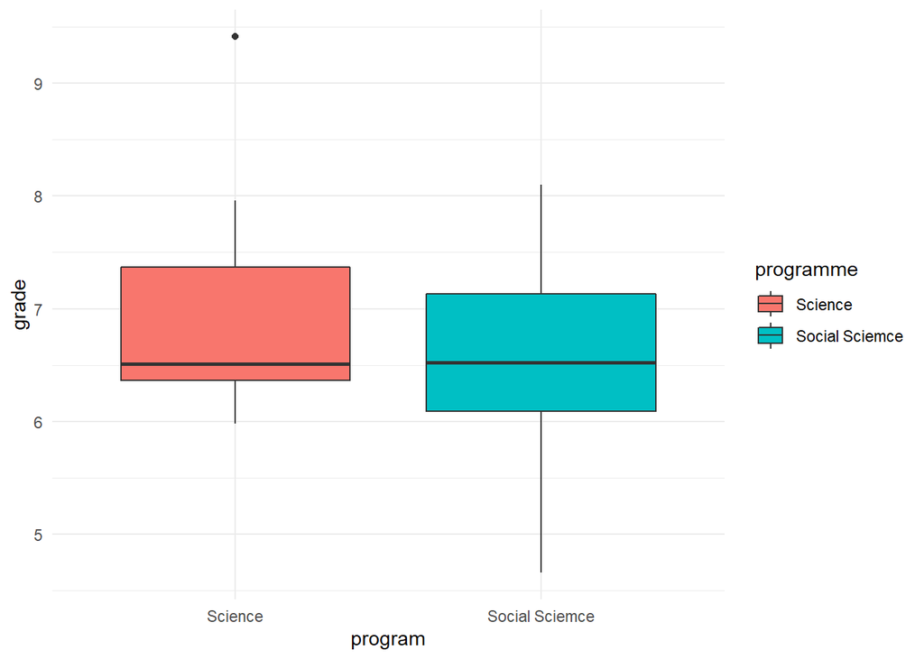

```r
ggplot(data = gg_students, aes(x = programme, y = student_grade, fill = programme)) +
  geom_boxplot() +
  theme_minimal() +
  labs(x = "program", y = "grade")
```

11. What do each of the horizontal lines in the boxplot mean? What do the vertical lines (whiskers) mean?

The horizontal line indicates the median grade in each program, the vertical line implies the quartile of each program.

12. Comparison of distributions across categories can also be done by adding a fill aesthetic to the density plot you made earlier. Try this out. To takecare of the overlap, you might want to add some transparency in the geom_density() function using the alpha argument.

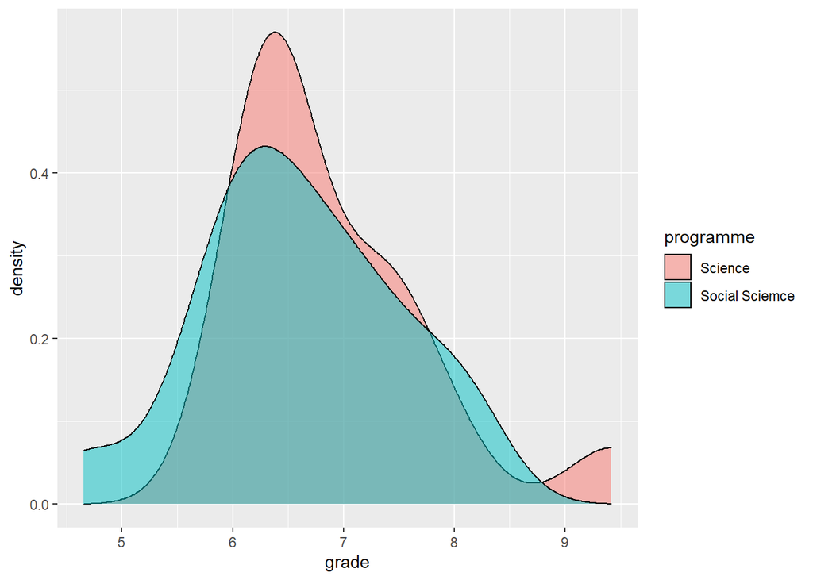

```r
ggplot(data = gg_students, aes(x = student_grade, fill = programme)) +
  geom_density(alpha = .5) +
  labs(x = "grade")
```

13. Create a bar plot of the variable Years from the Hitters dataset.

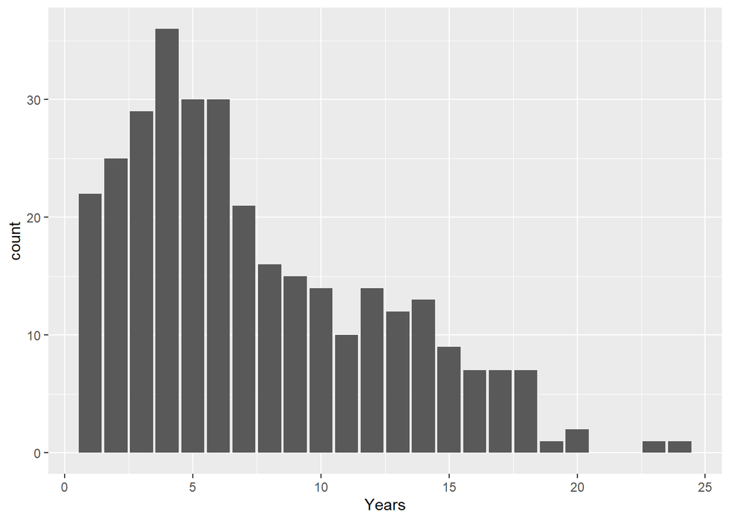

```r
Hitters %>%
  ggplot(aes(x = Years)) +
  geom_bar()
```

14. Use geom_line() to make a line plot out of the first 200 observations of the variable Volume (the number of trades made on each day) of the Smarket dataset. You will need to create a Day variable using mutate() to map to the x-position. This variable can simply be the integers from 1to 200. Remember, you can select the first 200 rows using Smarket[1:200, ] .

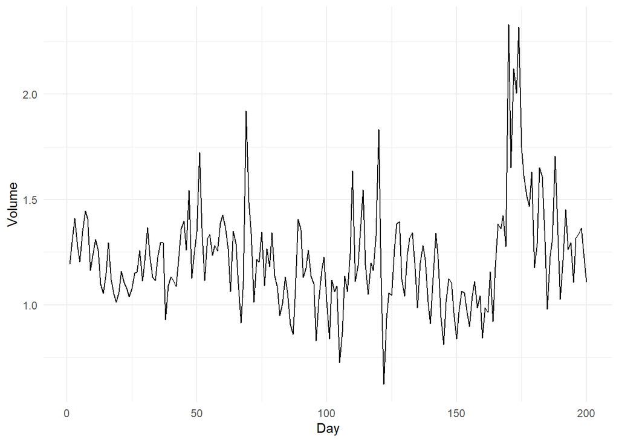

```r
Smarket[1:200,] %>%
  mutate(Day = 1:200) %>%
  ggplot(aes(x = Day, y = Volume)) +
  geom_line() +
  theme_minimal()
```

15. Give the line a nice colour and increase its size . Also add points of the same colour on top.

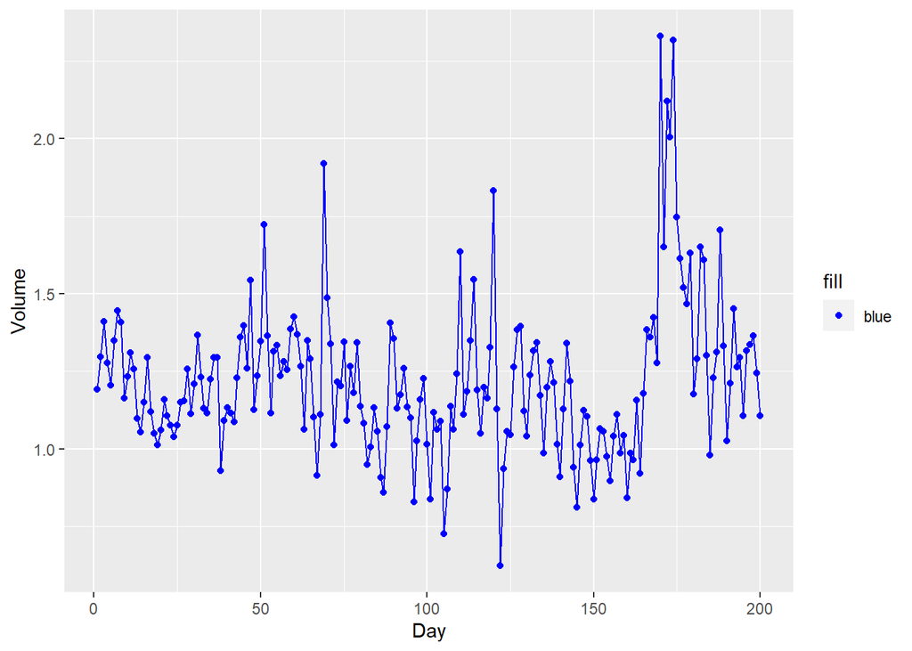

```r
Smarket[1:200,] %>%
  mutate(Day = 1:200) %>%
  ggplot(aes(x = Day, y = Volume, fill = "blue")) +
  geom_line(color = "blue") +
  geom_point(color = "blue")
```

16. Use the function which.max() to find out which of the first 200 days has the highest trade volume and use the function max() to find out howlarge this volume was.

```r
which.max(Smarket[1:200,]$Volume) #170
```

```
## [1] 170
```

```r
max(Smarket[1:200,]$Volume) #2.33083
```

```
## [1] 2.33083
```

17. Use geom_label(aes(x = your_x, y = your_y, label = “Peak volume”)) to add a label to this day. You can use either the values or call the functions. Place the label near the peak!

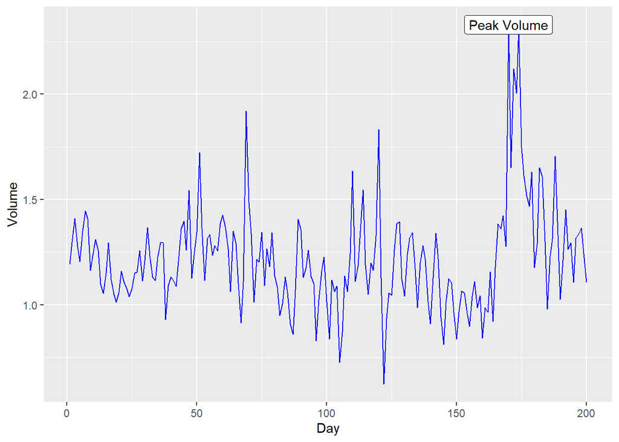

```r
Smarket[1:200,] %>%
  mutate(Day = 1:200) %>%
  ggplot(aes(x = Day, y = Volume)) +
  geom_line(color = "blue") +
  geom_label(x = 170, y = 2.33083, label = "Peak Volume")
```

18. Create a data frame called baseball based on the Hitters dataset. In this data frame, create a factor variable which splits players’ salary range into 3 categories. Tip: use the filter() function to remove the missing values, and then use the cut() function and assign nice labels to the categories. In addition, create a variable which indicates the proportion of career hits that was a home run.

```r
baseball <- Hitters %>%
  drop_na(Salary) %>%
  mutate(salary_range = cut(Salary, breaks = 3, labels = c("Low", "Medium", "High")),
         hr_pro = CHmRun / CHits)
```

19. Create a scatter plot where you map CWalks to the x position and the proportion you calculated in the previous exercise to the y position. Fix the yaxis limits to (0, 0.4) and the x axis to (0, 1600) using ylim() and xlim() . Add nice x and y axis titles using the labs() function. Save the plot asthe variable baseball_plot .

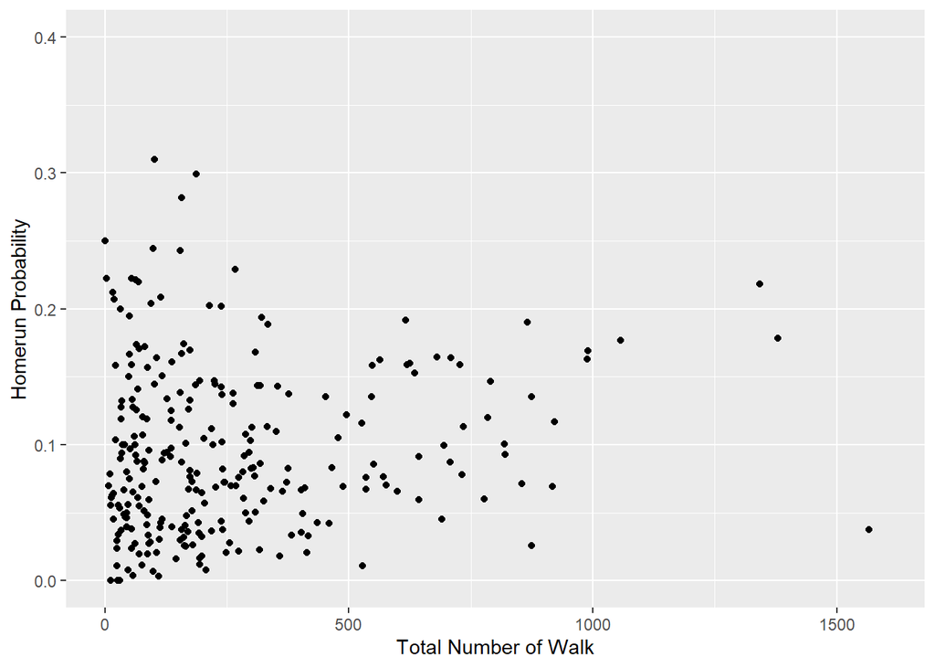

```r
ggplot(data = baseball, aes(x = CWalks, y = hr_pro)) +
  geom_point() +
  labs(x = "Total Number of Walk", y = "Homerun Probability") +
  xlim(0, 1600) +
  ylim(0, 0.4)
```

20. Split up this plot into three parts based on the salary range variable you calculated. Use the facet_wrap() function for this; look at the examples in the help file for tips.

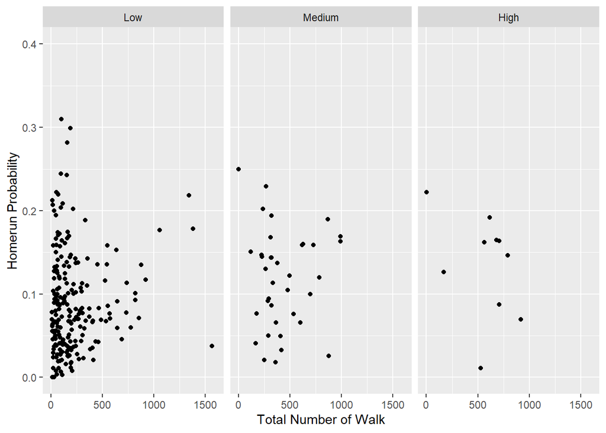

```r
ggplot(data = baseball, aes(x = CWalks, y = hr_pro)) +
  geom_point() +
  labs(x = "Total Number of Walk", y = "Homerun Probability") +
  xlim(0, 1600) +
  ylim(0, 0.4) +
  facet_wrap("salary_range")
```

21. Create an interesting data visualisation based on the Carseats data from the ISLR package.

```r
head(Carseats)
```

```
##   Sales CompPrice Income Advertising Population Price ShelveLoc Age Education
## 1  9.50       138     73          11        276   120       Bad  42        17
## 2 11.22       111     48          16        260    83      Good  65        10
## 3 10.06       113     35          10        269    80    Medium  59        12
## 4  7.40       117    100           4        466    97    Medium  55        14
## 5  4.15       141     64           3        340   128       Bad  38        13
## 6 10.81       124    113          13        501    72       Bad  78        16
##   Urban  US
## 1   Yes Yes
## 2   Yes Yes
## 3   Yes Yes
## 4   Yes Yes
## 5   Yes  No
## 6    No Yes
```

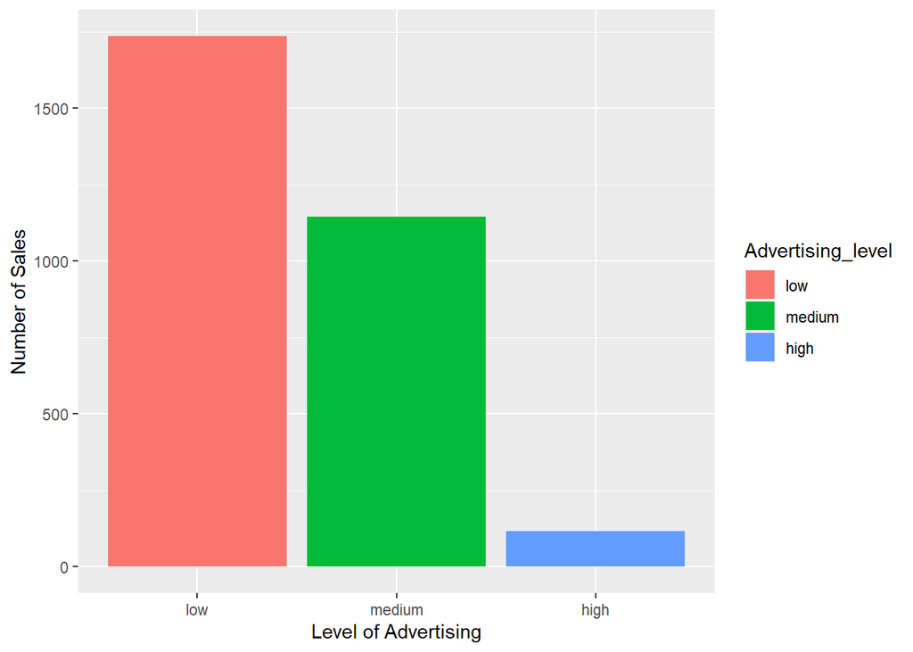

```r
Carseats %>%
  mutate(Advertising_level = cut(Advertising, breaks = 3, labels = c("low", "medium", "high"))) %>%
  ggplot(aes(x = Advertising_level, y = Sales, fill = Advertising_level)) +
  geom_bar(stat = "identity") +
  labs(x = "Level of Advertising", y = "Number of Sales")
```